# Part I - (Dataset Exploration Title)

### Discuss the distribution(s) of your variable(s) of interest. Were there any unusual points? Did you need to perform any transformations?

The variable I am most interested in, duration, has a long-tailed distribution. It was interesting to see that there are more than 3,000 datapoints of just 1 minute of use! The mode for this variable is 5 minutes, which intuitively makes sense, and then tails off up to the 60 minute mark. There was one datapoint of 85,444 seconds (1,424 minutes or 23.7 hours) which would seem like somebody took a bike home overnight. This seriously skewed the plot which is why I chose 60 minutes as the maximum.

It was also interesting to note that there are three times as many male users as there are female users, which will be cross-referenced against trip duration later.

### Of the features you investigated, were there any unusual distributions? Did you perform any operations on the data to tidy, adjust, or change the form of the data? If so, why did you do this?

First, I had to adjust the "duration_sec" variable by dividing it by 60 to represent minutes instead. Having the data in seconds made in much harder to read, and is not very user-friendly. For instance, reading "15 minutes" makes intuitive sense to a person, where "900 seconds" may not.

I also noticed that the "member_birth_year" variable had an impossibe value which is likely an entry error - a member with a birth year of 1878. After looking at the data, I decided to start the birth years at 1940 and bin it by decade.

## Bivariate Exploration

In this section, I'm going to look further into the ride duration variable by cross-comparing it with user types, user age and user gender. This will give us a great look into who the customers are for this service, which is fundamental to answering our question - what marketing segments exist within this dataset?

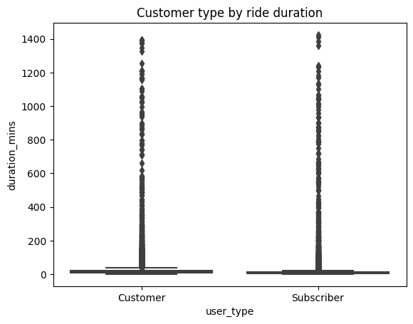

```python
ax1 = sns.boxplot(data=df, x="user_type", y="duration_mins", color="tab:blue");
plt.title("Customer type by ride duration");
```

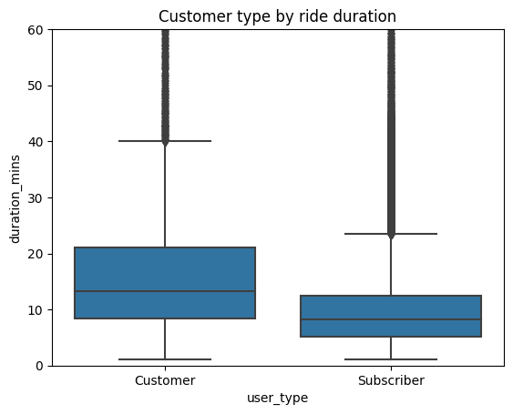

```python
# Because the plot above is stretched way out on the y-axis, I have introduced a y-limit of 60 minutes.

ax1 = sns.boxplot(data=df, x="user_type", y="duration_mins", color="tab:blue")
plt.ylim(0,60);
plt.title("Customer type by ride duration");
```

This shows that the subscriber users have shorter trips on average than the casual customers of the service. It also shows that trips above 40 minutes are outliers so our marketing efforts should focus on trips under this limit.

```python
def scatterfunction (xL, yL, title):
    plt.title(title)
    plt.xlabel(xL)
    plt.ylabel(yL)
```

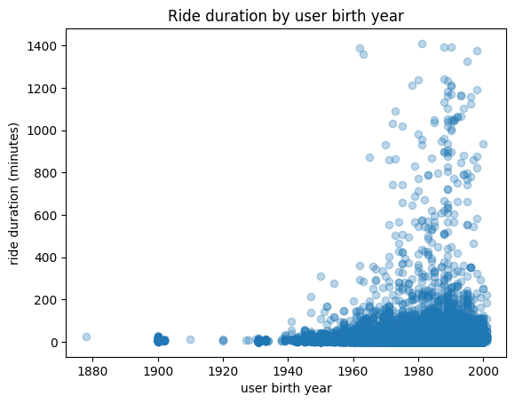

```python
plt.scatter(data=df, x="member_birth_year", y="duration_mins", alpha=0.3)
scatterfunction("user birth year", "ride duration (minutes)", "Ride duration by user birth year");
```

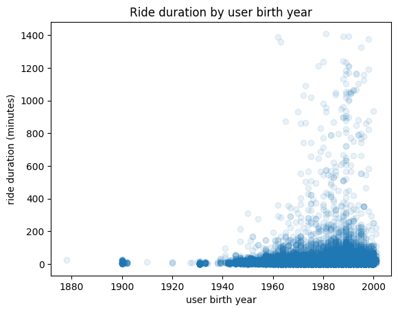

```python
# Running the same plot as above, but changing the alpha to get a better look into the
# heavily clustered section.

plt.scatter(data=df, x="member_birth_year", y="duration_mins", alpha=0.1);
scatterfunction("user birth year", "ride duration (minutes)", "Ride duration by user birth year");
```

I thought this was interesting. I suspected that a large volume of users would be born 1980 and after, but I did not expect a significant volume of users from 1950 to 1980. This could represent a user group that we can target with our marketing efforts.

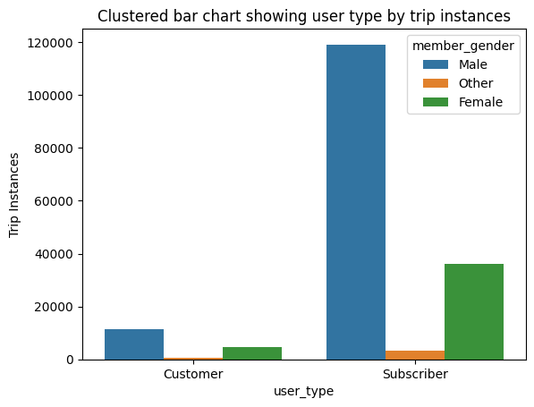

```python
# This plot will separate out the gender split by casual customer and subscriber types.

sns.countplot(data=df, x="user_type", hue="member_gender");
plt.title("Clustered bar chart showing user type by trip instances")
plt.ylabel("Trip Instances");
```

This reinforces our insight from before - the male subscriber category dominates the platform and is out best segment to market to, followed by the female subscriber user group.

### Talk about some of the relationships you observed in this part of the investigation. How did the feature(s) of interest vary with other features in the dataset?

I was interested to see that in the box plots, the non-subscribed "customer" users had a higher average usage time by nearly 50% thank the "subscriber" users. My assumption is that the "subscriber" users use the service to travel to and from work, while the "customer" users use the service for more leisurely trips. From a marketing perspective, this could be quite useful information.

In the scatter plot, you can see that the longer rides (of 120 minutes or more) do not spike until the birth year reaches the 1960's. After the 1940's, there is a positive correlation between ride duration and later birth year that can be viewed slightly better by reducing the alpha value.

### Did you observe any interesting relationships between the other features (not the main feature(s) of interest)?

I wanted to get a greater insight on user gender in relation to user type. The countplot above shows that the 'male subscriber' category makes, by far, the most trips on the platform at around three times as many trips as 'female subscribers'. In turn, the 'female subscriber' category makes about three times as many trips as the 'male non-subscribers'.

Although not a relationship, I thought the cluster of users who have listed their birth year as 1900 was quite funny. This is not likely to be a default setting, and could be a user entry issue on the sign-up form.

Additionally, the scatter plot allows us to visually see that given the volume of data points we have, the volume of super-long duration rides is actually not that significant in comparison to rides under ~200 minutes in duration. This is backed up by the Q3 and "maximum" box plot values and the long column of outliers.

## Multivariate Exploration

In this section, I'm going to use what I would normally start any investigation with - a scatter matrix. This will show what a plot of a series of variables against my primary variable of duration. I also want to know what other variable correlations there are throughout the dataset, and this gives me a visual way to find that out.

I'm also interested in how the different gender splits use the service itself. I'm going to use a pair of facet grids to answer whether a particular gender group has a preference for longer or shorter ride duration, and if there are certain start or end stations that are more commonly used by a particular gender group.

```python
# Setting a variable for the columns that I'm interested in running through the scatter matrix.

df2 = pd.DataFrame(data=df, columns=["duration_mins", "start_station_id", "end_station_id", "bike_id",
                                    "member_birth_year"]);
```

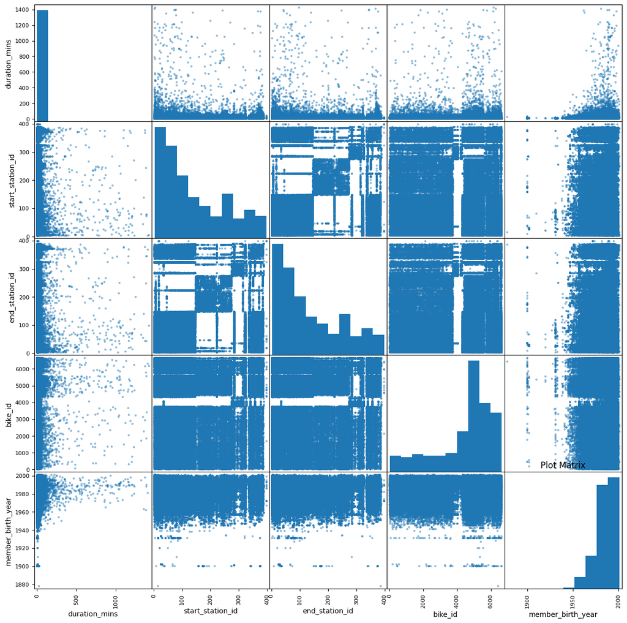

```python
pd.plotting.scatter_matrix(df2, figsize=(15,15));
```

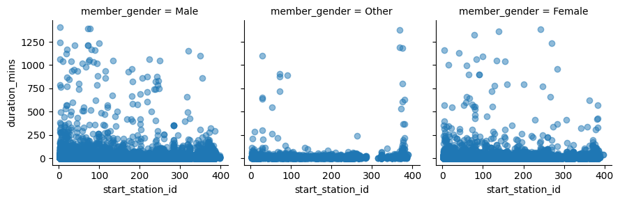

```python
# This pair of facet grids will provide better insight into station usage and service duration usage split by gender groups.

g = sns.FacetGrid(data=df, col='member_gender')
g.map(plt.scatter, 'start_station_id','duration_mins', alpha=0.5);
```

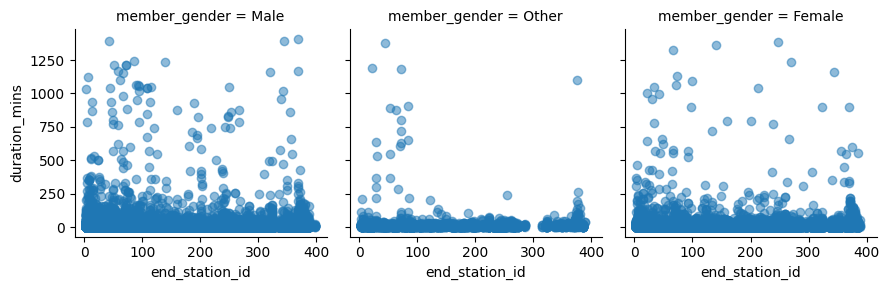

```python
g2 = sns.FacetGrid(data=df, col='member_gender')
g2.map(plt.scatter, 'end_station_id','duration_mins', alpha=0.5);
```

### Talk about some of the relationships you observed in this part of the investigation. Were there features that strengthened each other in terms of looking at your feature(s) of interest?

This scatter plot shows why actually prefer to use this plotting method as one of my first exploratory steps. It lets you visually discover relationships that might not otherwise be obvious.

There's a really interesting valley in duration when it comes to the "end_station_id" columns and "bike_id" columns. By looking up the station id's that fit into this valley you would be able to identify a concentrated market pocket that you could target.

There also appears to be a concentration of trips from "start_station" 0-50. Again, marketing collateral could be targeted around these stations for this segment.

Also, there's a small spike of users at stations around 380 that identify as 'other' in terms of gender. What's different about this area compared to other stations? It's not within the scope of the questions I've asked, but it was interesting.

### Were there any interesting or surprising interactions between features?

You can see that the same section of low-duration rides also correlates to a later birth year. I would wager that this block consists of CBD stations.

It's also interesting to note that there are obvious blocks of trips that begin and end at either the same station or a nearby one. These are represented by sold blocks on the "start_station_id" / "end_station_id" plot. However, there are also a few stations which have solid lines across the "end_station_id" axis, which I find unusual - what is it about these stations that lead to them having a much higher rate of trips that end at a different station?

## Conclusions

This is not a very diverse dataset in terms of variables. Instead, there is a large quantity of data across these variables which is great for answering our question of whether or not there are market segments that we can target.

We found that:

1. The 'male-subscriber' market segment makes up a the vast majority of the user base, with about 3 times the second largest segment. That segment is the 'female-subscriber' group, which is itself about 3 times larger than the third largest group.
2. While most users are born after 1980, there is also a sizeable (about 35,000 trips), active market segment born between 1960 and 1980 that could be targeted as a segment by itself.
3. There are cases of long-duration usage (over 60 minutes) but according to the dataset anything over 40 minutes is an outlier so this is probably not a market segment worth targeting.
4. Working under the assumption that the station id's are coded by geographic proximity, there is a clear geogpraphic area around stations 275 to 325 which has a relatively concentrated user base of users born 1980 or after. However, this market segment is also somewhat small in terms of trips taken and more information is needed to determine if it should be invested in. For this reason, it will not be included in the final report.